# Assignment 7

Jiaming Xu

# Problem 1:

## 1:

```r
library(httr)
library(rvest)
library(tidyverse)
```

xpath used for nodes navigation. There are two tables in this html, I located the first one by defind data-sort-type=“text” which appears only in the first table. Then navigated to parent node twice, then convert it to table.

Clean references and percentage symbol.

```r
url = "https://en.wikipedia.org/wiki/List_of_countries_by_percentage_of_population_living_in_poverty"
html_raw_data <- read_html(url)
df <- html_raw_data %>%
    html_nodes(xpath = '//table//th[@data-sort-type="text"]/../..') %>%
    html_table()
df <- df[[1]] %>% as_tibble()

df_clean <- df %>%
    rename_with(~ gsub("\\[\\d+?\\]", "", .x)) %>%
    mutate(`< $1.90` = str_remove_all(`< $1.90`, "%")) %>%
    mutate(`< $3.20` = str_remove_all(`< $3.20`, "%")) %>%
    mutate(`< $5.50` = str_remove_all(`< $5.50`, "%")) %>%
    mutate(`< $1.90` = str_remove_all(`< $1.90`, '\\[\\d+?\\]')) %>%
    mutate(`< $3.20` = str_remove_all(`< $3.20`, '\\[\\d+?\\]')) %>%
    mutate(`< $5.50` = str_remove_all(`< $5.50`, '\\[\\d+?\\]')) %>%
    type_convert()
glimpse(df_clean)
```

```
Rows: 164
Columns: 6
$ Country   <chr> "Albania", "Algeria", "Angola", "Argentina", "Armenia", "Australia", "Austria",…
$ `< $1.90` <dbl> 1.3, 0.4, 49.9, 1.5, 1.1, 0.5, 0.6, 0.0, 6.8, 0.0, 0.1, 18.0, 49.6, 1.5, 3.2, 0…
$ `< $3.20` <dbl> 8.2, 3.7, 72.0, 5.0, 10.0, 0.7, 1.0, 0.0, 52.5, 0.0, 0.2, 43.0, 76.2, 12.2, 8.0…
$ `< $5.50` <dbl> 33.8, 28.6, 89.3, 14.0, 44.0, 0.7, 1.0, 7.0, 84.3, 0.2, 0.3, 51.0, 90.6, 38.6, …
$ Year      <int> 2017, 2011, 2018, 2019, 2019, 2014, 2018, 2005, 2016, 2019, 2018, 2021, 2015, 2…
$ Continent <chr> "Europe", "Africa", "Africa", "South America", "Asia", "Oceania", "Europe", "As…
```

## 2:

Ascending order is: Europe, Asia,Europe, South America, North America, Asia, Oceania, and Africa.

In general, only 5% people in Europe are living with less than $5.50 a day, with standard deviation 9. Asia,Europe countries have similar percentage, about 6.85%, but less deviation, only 4.5%.

Asia is the most unbalanced continent, followed by Oceania, Africa, and North America. This means wealthy and poor counties have big differences.

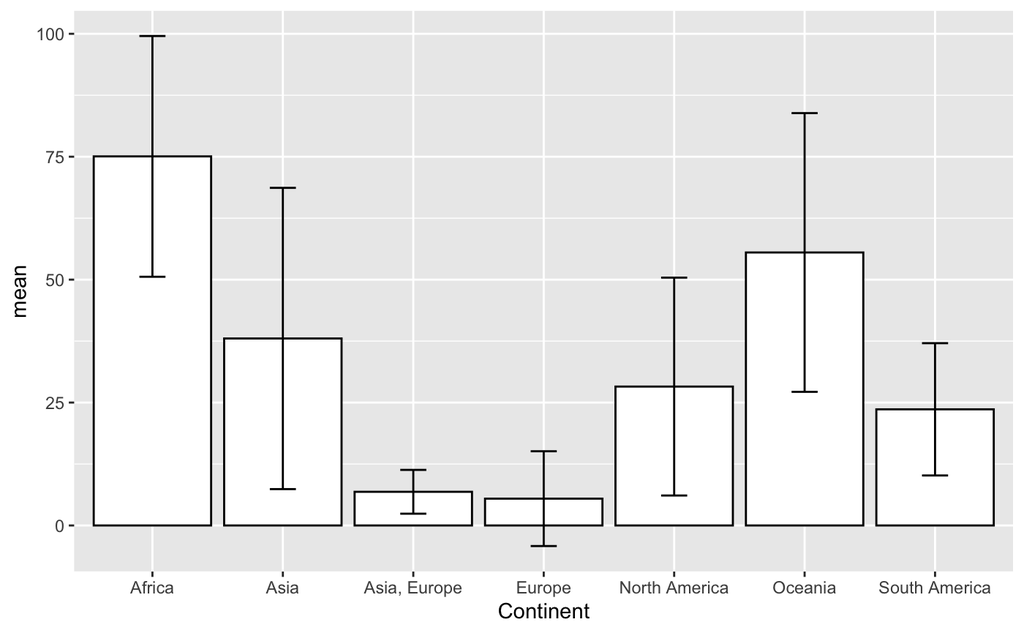

```r
df_clean %>%
    group_by(Continent) %>%
    summarise( mean= mean(`< $5.50`),
               sd = sd(`< $5.50`)  ) %>%
    arrange(mean) %>%
    ggplot(aes(x = Continent, y = mean)) +
        geom_bar(stat = 'identity', fill='white', color='black') +
        geom_errorbar(aes(ymin=mean-sd, ymax=mean+sd), width=.2,
                      position = position_dodge(0.9))
```

## 3:

From graph below we can see, 9 out of top 10 poor country are from Africa, one from Asia. Madagascar has 98% people living under $5.5 a day, the highest percentage on the Earth.

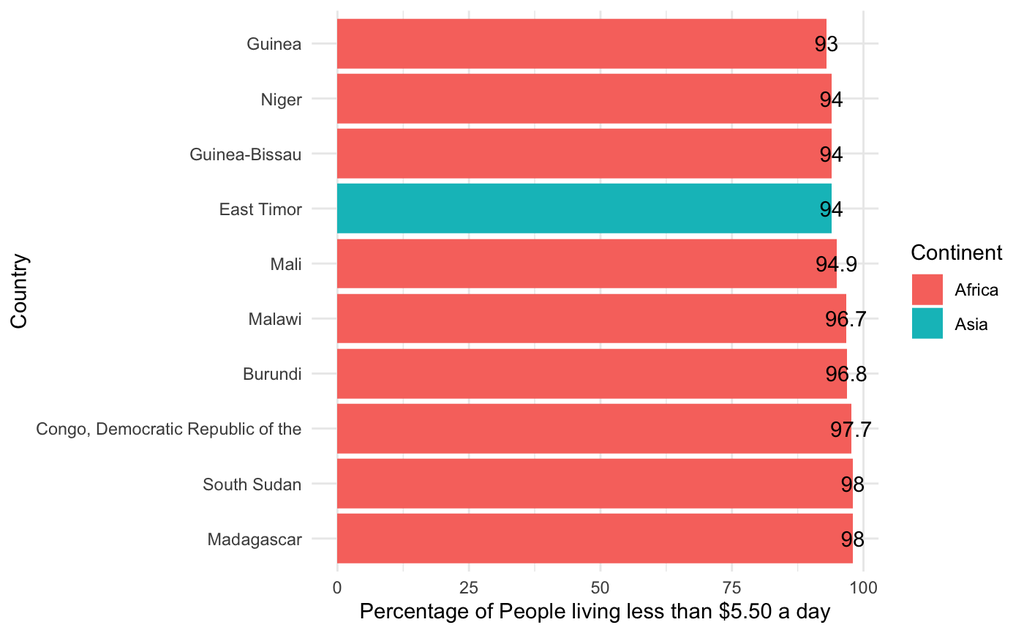

```r
df_clean %>%
    arrange(desc(`< $5.50`)) %>%
    slice(1:10) %>%
    ggplot(aes(x = reorder(Country, -`< $5.50`), y = `< $5.50`, fill = Continent)) +
        geom_bar(stat = 'identity') +
        coord_flip() +
        labs( y = "Percentage of People living less than $5.50 a day",
              x = "Country") +
        geom_text(aes(label = `< $5.50`)) +
        theme_minimal()
```

## 4:

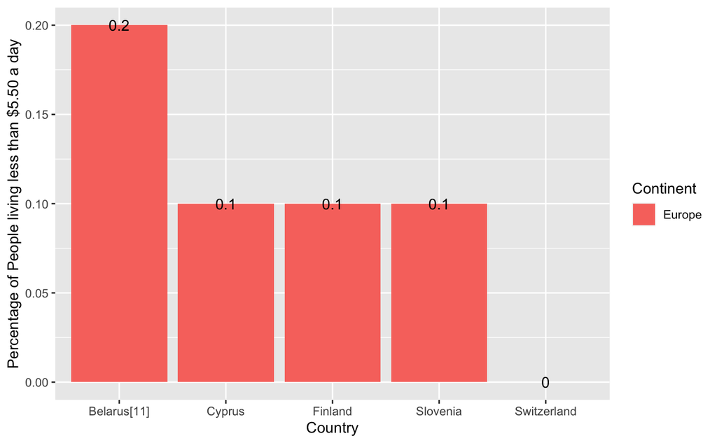

```r
df_clean %>%
    arrange((`< $5.50`)) %>%
    slice(1:5) %>%
    ggplot(aes(x = reorder(Country, -`< $5.50`), y = `< $5.50`, fill = Continent)) +
        geom_bar(stat = 'identity') +
        labs( y = "Percentage of People living less than $5.50 a day",
              x = "Country") +
        geom_text(aes(label = `< $5.50`))
```

```r
df_clean %>%
    filter((`< $3.20` < 0.2)) %>%
    count( Continent)
```

| Continent | n |
| --- | --- |
| Asia | 3 |
| Europe | 9 |

```r
df_clean %>%
    filter((`< $1.90` < 0.2)) %>%
    count( Continent)
```

| Continent | n |
| --- | --- |
| Asia | 8 |
| Asia, Europe | 1 |
| Europe | 16 |
| South America | 1 |

We see all top 5 countries with lowest percentage of living expenses smaller than $5.50 a day are from Europe, which shows European countries provide high welfare for their people. Of course, this is the consequence of Industrial Revolutions and triangle trade.

I chose 0.2 as the threshold for $3.20 and $1.90 analysis. There are 3 countries in Asia and 9 countries in Europe which only 0.2 % of their people living less than $3.20. For $1.90 expenses a day, there are 8 countries in Asia, 1 country in Asia-Europe, 16 countries in Europe and only one country in south America have less than 0.2% people living with less than $1.90. No country in Africa lists above.

## 5:

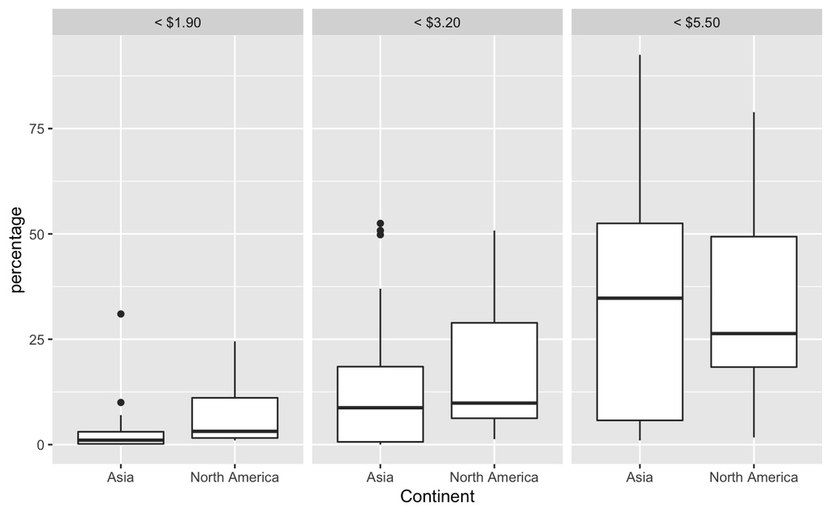